# 99_graficas_apoyo

[figure not shown]

Trabajo de fin de máster

Máster Universitario en Ciencia de Datos

Estudios de Informática, Multimedia y Telecomunicación

Azucena González Muiño

# Recursos visuales adicionales

En este *notebook* se generan gráficas adicionales a las existentes en el análisis exploratorio de datos surgidas durante la elaboración de la memoria del TFM.

```python
# Manipulación de datos
import numpy as np
import pandas as pd
from pandas.api.types import CategoricalDtype

# Expresiones regulares
import re

# Creación de gráficas
import seaborn as sns
import matplotlib.pyplot as plt
%matplotlib inline

# Generación de mapas
import geopandas as gpd
```

## 0. Definición de funciones

Este apartado recoge varias funciones relativas a generación de gráficos y cálculos que se emplean en las siguientes secciones.

```python
# Función que genera una gráfica de barras basada en porcentajes
def percentage_plot(data, x, y, title, x_label, y_label='Porcentaje', palette='Blues_r', height=5, aspect=2,
                    orient='v', limit_y=True, show_percentage=True, order=None):

    # Se genera un nuevo dataframe con los datos agrupados por x y el conteo
    # de posibles valores de y
    temp = data.groupby(x)[y].value_counts(normalize=True)

    # Se pasa a formato de porcentaje
    temp = temp.mul(100).rename('Percentage').reset_index()

    # Orientación vertical
    if orient == 'v':
        g = sns.catplot(x=x, y='Percentage', hue=y, kind='bar', data=temp, palette=palette,
                        height=height, aspect=aspect, order=order)
        if limit_y: g.ax.set_ylim(0, 100)

        # Se añade el porcentaje a cada barra (con excepción del 0% y el 100%)
        if show_percentage:
            for pos in g.ax.patches:
                if pos.get_height() > 0 and pos.get_height() < 100:
                    label = str(pos.get_height().round(2)) + '%'
                    pos_x = pos.get_x()
                    pos_y = pos.get_height() + 0.5
                    g.ax.text(pos_x, pos_y, label)
                    sns.despine(left=False, right=False, bottom=False, top=False)
    # Orientación horizontal
    else:
        g = sns.catplot(x='Percentage', y=x, hue=y, kind='bar', data=temp, palette=palette,
                        height=height, aspect=aspect, orient=orient, order=order)
        if show_percentage:
            for pos in g.ax.patches:
                if pos.get_width() > 0 and pos.get_width() < 100:
                    label = str(pos.get_width().round(2)) + '%'
                    pos_x = pos.get_width() + 0.5
                    pos_y = pos.get_y() + 0.25
                    g.ax.text(pos_x, pos_y, label)
                    sns.despine(left=False, bottom=False, top=False)

    sns.set_style('whitegrid')
    plt.title(title, fontsize=14)
    plt.xlabel(x_label, fontsize=12)
    plt.ylabel(y_label, fontsize=12)

    return plt

# Función para personalizar la información de una gráfica de sectores:
# además del porcentaje de cada sección, se obtiene el número de instancias
def custom_autopct(portions):
    def my_autopct(pct):
        value = int(round(pct*sum(portions)/100.0))
        return '{p:.2f}%\n({v:d})'.format(p=pct,v=value)
    return my_autopct

# Función que genera un gráfico de sectores
def pie_chart(data, x, title, labels, colors, startangle=90):

    # Se recoge el número de instancias de cada clase
    portions = data[x].value_counts()

    # Se configura el gráfico de tarta
    fig1, axis1 = plt.subplots()
    axis1.pie(portions, labels=labels, autopct=custom_autopct(portions), colors=colors, startangle=startangle)
    plt.title(title, size=14)

    # Se asegura que la gráfica se muestre como un círculo perfecto
    axis1.axis('equal')

    return plt

# Función que calcula una ratio a partir de dos valores pasados como parámetros
def calculate_ratio(x, y):
    return x/y*100
```

## 1. Carga de los conjuntos de datos

Se realiza la carga del fichero que contiene los datos relativos a actuaciones policiales de tipo "detención y registro" de la zona de Londres (British Transport Police, City of London Police y Metropolitan Police) y se repite el preprocesamiento efectuado durante el análisis exploratorio.

```python
# Carga de datos policiales
police_data = pd.read_csv('./datasets/full-stop-and-search.csv',
                          dtype={'Part of a policing operation':'boolean',
                                 'Outcome linked to object of search':'boolean',
                                 'Removal of more than just outer clothing':'boolean'},
                          parse_dates=['Date'])

# ELiminación de registros anteriores a la fecha de inicio establecida
police_data = police_data.drop(police_data[police_data['Date'] < '2017-04-01'].index)

# Se simplifican los nombres de algunas columnas
police_data = police_data.rename({'Part of a policing operation': 'Part-operation',
                                  'Policing operation': 'Operation',
                                  'Age range': 'Age-range',
                                  'Self-defined ethnicity': 'Self-ethnicity',
                                  'Officer-defined ethnicity': 'Officer-ethnicity',
                                  'Object of search': 'Object',
                                  'Outcome linked to object of search': 'Outcome-object',
                                  'Removal of more than just outer clothing': 'More-JOG'}, axis='columns')

# Carga de datos relativos a localizaciones
loc_data = pd.read_csv('./datasets/full-stop-and-search-locs.csv')

# Se cruzan los datasets de datos policiales y de localizaciones
police_data = pd.merge(police_data, loc_data, how="left", on=["Latitude", "Longitude"])

# Se elimina la información de la zona horaria del campo de fecha
police_data['Date'] = police_data['Date'].apply(lambda x: x.tz_localize(None))

# Se genera un nuevo campo para facilitar la agrupación de datos por año y mes
police_data['Year-month'] = pd.to_datetime(police_data['Date']).dt.to_period('M')

# Se seleccionan sólo los registros pertenecientes a Greater London
london_data = police_data[(police_data['Borough'].notnull())]

# Se eliminan los registros con el campo Outcome vacío
london_data = london_data.dropna(subset=['Outcome'])

# Se genera la variable objetivo
london_data['Further-action'] = london_data['Outcome'].apply(lambda x: False if 'no further action' in x else True)
london_data.head()
```

|  | Type | Date | Part-operation | Operation | Latitude | Longitude | Gender | Age-range | Self-ethnicity | Officer-ethnicity | Legislation | Object | Outcome | Outcome-object | More-JOG | Source | Address | Borough | Year-month | Further-action |
| --- | --- | --- | --- | --- | --- | --- | --- | --- | --- | --- | --- | --- | --- | --- | --- | --- | --- | --- | --- | --- |
| 9 | Person search | 2017-04-02 16:40:00 | <NA> | NaN | 51.5170 | -0.177458 | Male | 25-34 | White - White British (W1) | White | Police and Criminal Evidence Act 1984 (section 1) | Stolen goods | Suspect arrested | True | False | BTP | London Paddington Platform 6, Grand Union Cana... | Westminster | 2017-04 | True |
| 10 | Person search | 2017-04-02 17:06:00 | <NA> | NaN | 51.5285 | -0.133415 | Male | 25-34 | White - Any other White ethnic background (W9) | White | Police and Criminal Evidence Act 1984 (section 1) | Stolen goods | Local resolution | True | False | BTP | Euston Railway Station, Phoenix Road, Somers T... | Camden | 2017-04 | True |
| 11 | Person search | 2017-04-02 18:15:00 | <NA> | NaN | 51.5530 | -0.105784 | Male | 10-17 | White - White British (W1) | White | Police and Criminal Evidence Act 1984 (section 1) | Stolen goods | Suspect arrested | True | False | BTP | Drayton Park, Highbury, London Borough of Isli... | Islington | 2017-04 | True |
| 13 | Person search | 2017-04-02 23:00:00 | <NA> | NaN | 51.5285 | -0.133415 | Female | over 34 | Asian or Asian British - Any other Asian ethni... | Asian | Police and Criminal Evidence Act 1984 (section 1) | Offensive weapons | Nothing found - no further action | True | False | BTP | Euston Railway Station, Phoenix Road, Somers T... | Camden | 2017-04 | False |
| 14 | Person search | 2017-04-03 14:30:00 | <NA> | NaN | 51.5395 | 0.080833 | Male | 18-24 | White - White British (W1) | White | Misuse of Drugs Act 1971 (section 23) | Controlled drugs | Suspect summonsed to court | True | False | BTP | Barking, Station Parade, London Borough of Bar... | Barking and Dagenham | 2017-04 | True |

Se carga el fichero con los datos sobre población y distribución racial extraídos del censo de 2011.

```python
# Carga de datos relativos a la distribución de población por etnia y zonas
ethnic_data = pd.read_csv('./datasets/ethnic_ratios_all_ages.csv', index_col=0)

# Se recupera el listado de distritos
boroughs = loc_data['Borough'].dropna().unique()

# Se crea una nueva columna con el distrito eliminando los números que aparecen en los códigos MSOA. Posteriormente
# se filtran sólo los registros correspondientes a Londres
ethnic_data['Borough'] = ethnic_data['MSOA name'].apply(lambda x: re.sub('\s\d+$', '', x))
ethnic_data = ethnic_data.loc[ethnic_data['Borough'].isin(boroughs)]
ethnic_data = ethnic_data.drop(['MSOA name', 'MSOA'], axis=1)

# Se crea una nueva columna para los registros correspondientes a la población blanca consolidados
ethnic_data['White'] = ethnic_data['White British'] + ethnic_data['White Other']
ethnic_data.rename(columns={'Mixed Other':'Other'}, inplace=True)

# Se genera un dataframe que acumula los datos por distrito
ethnic_data = ethnic_data.groupby('Borough', as_index=False).agg(
    {'Asian': 'mean',
    'Black': 'mean',
    'Other': 'mean',
    'White': 'mean',
    'Total': 'sum'}
)

# Se calcula el número de residentes por raza y distrito
ethnic_data[['Asian', 'Black', 'Other', 'White']] = ethnic_data[
    ['Asian', 'Black', 'Other', 'White']].apply(lambda x: round(x*ethnic_data['Total']))
ethnic_data.head()
```

|  | Borough | Asian | Black | Other | White | Total |
| --- | --- | --- | --- | --- | --- | --- |
| 0 | Barking and Dagenham | 28963.0 | 37615.0 | 10721.0 | 108612.0 | 185911 |
| 1 | Barnet | 65446.0 | 27322.0 | 34676.0 | 228942.0 | 356386 |
| 2 | Bexley | 15226.0 | 19226.0 | 7145.0 | 190400.0 | 231997 |
| 3 | Brent | 107690.0 | 57584.0 | 33690.0 | 112251.0 | 311215 |
| 4 | Bromley | 15934.0 | 18089.0 | 13480.0 | 261890.0 | 309392 |

Se realiza la carga de los ingresos familiares por distrito.

```python
# Carga de datos relativos a la mediana de ingresos por hogar según el distrito
income_data = pd.read_csv('./datasets/modelled-household-income-estimates-borough.csv')

# Se muestra la información básica del dataset
print('Número de filas totales:', income_data.shape[0])
print('Número de atributos:', income_data.shape[1])
income_data.tail()

# Se filtran los datos por el año más reciente y se obtienen sólo los registros con la mediana
# para los distritos de Londres
recent_year = income_data['Year'].max()
income_data = income_data[(income_data['Year']==recent_year) &
                          (income_data['Measure']=='Median')]
boroughs = pd.unique(london_data['Borough'])
income_data = income_data.loc[income_data['Borough'].isin(boroughs)]
income_data = income_data.drop(['Code', 'Measure', 'Year'], axis=1)
income_data.head()
```

```
Número de filas totales: 1152
Número de atributos: 5
```

|  | Borough | Income |
| --- | --- | --- |
| 1104 | City of London | 63620 |
| 1105 | Barking and Dagenham | 29420 |
| 1106 | Barnet | 40530 |
| 1107 | Bexley | 36990 |
| 1108 | Brent | 32140 |

## 2. Generación de gráficas de apoyo

### 2.1 Porcentaje de actuaciones policiales por sexo

```python
# Se asigna un valor por defecto a los registros con valor desconocido
london_data['Gender'].fillna('Unknown')

# Cálculo del porcentaje de registros por sexo
gender_data = ((london_data['Gender']).value_counts(normalize=True, sort=True)*100).head(8)
gender_data = gender_data.to_frame().reset_index()
gender_data.columns = ['Gender', 'Percentage']
gender_data.head()
```

|  | Gender | Percentage |
| --- | --- | --- |
| 0 | Male | 93.205681 |
| 1 | Female | 6.738040 |
| 2 | Other | 0.056279 |

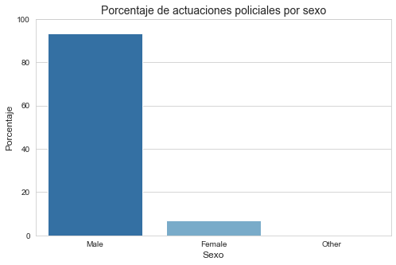

```python
# Gráfica con el porcentaje de actuaciones policiales por sexo
plt.figure(figsize=(8, 5))
sns.set_style('whitegrid')
sns.barplot(x='Gender', y='Percentage', data=gender_data, palette='Blues_r')
plt.xlabel('Sexo', size=12)
plt.ylabel('Porcentaje', size=12)
plt.title('Porcentaje de actuaciones policiales por sexo', size=14)
plt.ylim(0, 100)
plt.xticks(rotation=0)
plt.show()
```

### 2.2 Población por distrito

Se muestran a continuación varios mapas coropléticos de Londres con la población por distrito.

```python
# Se carga el mapa de Londres
london_map = gpd.read_file('./maps/london-boroughs-map.shp')

# Tabla con población por etnia y distrito
ethnic_data.head(33)
```

|  | Borough | Asian | Black | Other | White | Total |
| --- | --- | --- | --- | --- | --- | --- |
| 0 | Barking and Dagenham | 28963.0 | 37615.0 | 10721.0 | 108612.0 | 185911 |
| 1 | Barnet | 65446.0 | 27322.0 | 34676.0 | 228942.0 | 356386 |
| 2 | Bexley | 15226.0 | 19226.0 | 7145.0 | 190400.0 | 231997 |
| 3 | Brent | 107690.0 | 57584.0 | 33690.0 | 112251.0 | 311215 |
| 4 | Bromley | 15934.0 | 18089.0 | 13480.0 | 261890.0 | 309392 |
| 5 | Camden | 35916.0 | 17809.0 | 20666.0 | 145946.0 | 220338 |
| 6 | City of London | 940.0 | 193.0 | 443.0 | 5799.0 | 7375 |
| 7 | Croydon | 58373.0 | 71415.0 | 29728.0 | 203862.0 | 363378 |
| 8 | Ealing | 95825.0 | 35506.0 | 35232.0 | 171885.0 | 338449 |
| 9 | Enfield | 34543.0 | 51623.0 | 32671.0 | 193629.0 | 312466 |
| 10 | Greenwich | 28234.0 | 44936.0 | 16647.0 | 164739.0 | 254557 |
| 11 | Hackney | 25663.0 | 57242.0 | 28996.0 | 134368.0 | 246270 |
| 12 | Hammersmith and Fulham | 16416.0 | 21411.0 | 19885.0 | 124780.0 | 182493 |
| 13 | Haringey | 23917.0 | 47277.0 | 28446.0 | 155286.0 | 254926 |
| 14 | Harrow | 99830.0 | 19289.0 | 16500.0 | 103437.0 | 239056 |
| 15 | Havering | 11623.0 | 11386.0 | 6193.0 | 208030.0 | 237232 |
| 16 | Hillingdon | 67186.0 | 19213.0 | 18335.0 | 169202.0 | 273936 |
| 17 | Hounslow | 87012.0 | 16848.0 | 19387.0 | 130710.0 | 253957 |
| 18 | Islington | 18846.0 | 26247.0 | 20307.0 | 140725.0 | 206125 |
| 19 | Kensington and Chelsea | 15851.0 | 10526.0 | 20574.0 | 111698.0 | 158649 |
| 20 | Kingston upon Thames | 26055.0 | 3980.0 | 10525.0 | 119500.0 | 160060 |
| 21 | Lambeth | 21045.0 | 78760.0 | 30516.0 | 172765.0 | 303086 |
| 22 | Lewisham | 25299.0 | 74649.0 | 27627.0 | 148310.0 | 275885 |
| 23 | Merton | 35657.0 | 20550.0 | 13078.0 | 130408.0 | 199693 |
| 24 | Newham | 132389.0 | 61022.0 | 24705.0 | 89869.0 | 307984 |
| 25 | Redbridge | 112926.0 | 24586.0 | 19061.0 | 122397.0 | 278970 |
| 26 | Richmond upon Thames | 13063.0 | 2691.0 | 9785.0 | 161451.0 | 186990 |
| 27 | Southwark | 27471.0 | 76966.0 | 27204.0 | 156642.0 | 288283 |
| 28 | Sutton | 21976.0 | 9068.0 | 9523.0 | 149579.0 | 190146 |
| 29 | Tower Hamlets | 103956.0 | 18323.0 | 16197.0 | 115620.0 | 254096 |
| 30 | Waltham Forest | 53035.0 | 44045.0 | 24061.0 | 137107.0 | 258249 |
| 31 | Wandsworth | 34056.0 | 33476.0 | 21851.0 | 217611.0 | 306995 |
| 32 | Westminster | 31936.0 | 15373.0 | 34661.0 | 137425.0 | 219396 |

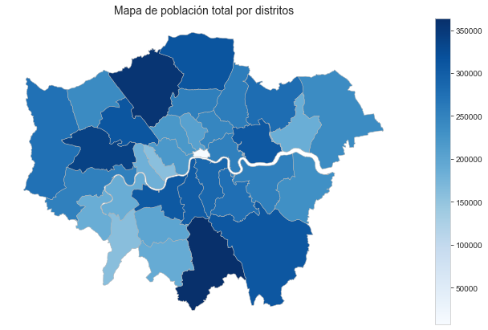

```python
# Se hace un join por distrito con los datos necesarios para generar el mapa
map_data = london_map.set_index('NAME').join(ethnic_data.set_index('Borough'))

# Se genera un mapa coroplético con la población por distritos
fig, ax = plt.subplots(figsize=(15, 7))
ax.axis('off')
ax.set_title('Mapa de población total por distritos', fontsize='14')
map_data.plot(column='Total', cmap='Blues', ax=ax, edgecolor='0.7', linewidth=0.5, legend=True)
```

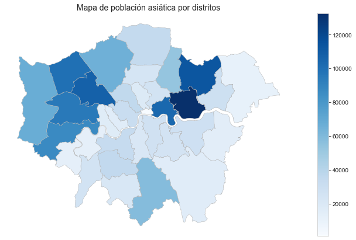

```python
# Se genera un mapa coroplético con la población asiática
fig, ax = plt.subplots(figsize=(15, 7))
ax.axis('off')
ax.set_title('Mapa de población asiática por distritos', fontsize='14')
map_data.plot(column='Asian', cmap='Blues', ax=ax, edgecolor='0.7', linewidth=0.5, legend=True)
```

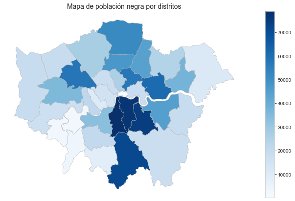

```python
# Se genera un mapa coroplético con la población negra
fig, ax = plt.subplots(figsize=(15, 7))
ax.axis('off')
ax.set_title('Mapa de población negra por distritos', fontsize='14')
map_data.plot(column='Black', cmap='Blues', ax=ax, edgecolor='0.7', linewidth=0.5, legend=True)
```

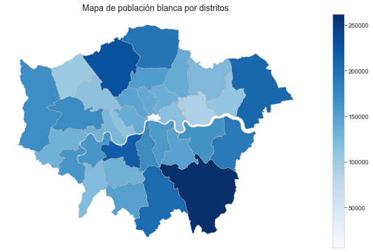

```python
# Se genera un mapa coroplético con la población blanca
fig, ax = plt.subplots(figsize=(15, 7))
ax.axis('off')
ax.set_title('Mapa de población blanca por distritos', fontsize='14')
map_data.plot(column='White', cmap='Blues', ax=ax, edgecolor='0.7', linewidth=0.5, legend=True)
```

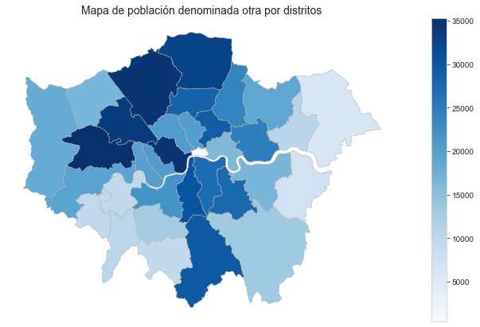

```python
# Se genera un mapa coroplético con la población 'otra'
fig, ax = plt.subplots(figsize=(15, 7))
ax.axis('off')
ax.set_title('Mapa de población denominada otra por distritos', fontsize='14')
map_data.plot(column='Other', cmap='Blues', ax=ax, edgecolor='0.7', linewidth=0.5, legend=True)
```

### 2.3 Ratio de actuaciones policiales por población y distrito

```python
# Se genera un nuevo conjunto de datos para estudiar la ratio entre actuaciones policiales
# y población por distrito
pop_london_data = london_data.groupby('Borough', as_index=False)['Latitude'].count()
pop_london_data.rename(columns={'Latitude': 'Num-stops'}, inplace=True)
tot_ethnic_data = ethnic_data[['Borough', 'Total']]

pop_london_data = pd.merge(pop_london_data, tot_ethnic_data, how='left', on=['Borough'])
pop_london_data['Ratio'] = calculate_ratio(pop_london_data['Num-stops'], pop_london_data['Total'])
pop_london_data.head(33)
```

|  | Borough | Num-stops | Total | Ratio |
| --- | --- | --- | --- | --- |
| 0 | Barking and Dagenham | 15208 | 185911 | 8.180258 |
| 1 | Barnet | 10797 | 356386 | 3.029580 |
| 2 | Bexley | 10674 | 231997 | 4.600922 |
| 3 | Brent | 28477 | 311215 | 9.150266 |
| 4 | Bromley | 20195 | 309392 | 6.527318 |
| 5 | Camden | 33966 | 220338 | 15.415407 |
| 6 | City of London | 5800 | 7375 | 78.644068 |
| 7 | Croydon | 34391 | 363378 | 9.464249 |
| 8 | Ealing | 28056 | 338449 | 8.289580 |
| 9 | Enfield | 17163 | 312466 | 5.492758 |
| 10 | Greenwich | 24707 | 254557 | 9.705881 |
| 11 | Hackney | 28869 | 246270 | 11.722500 |
| 12 | Hammersmith and Fulham | 17186 | 182493 | 9.417348 |
| 13 | Haringey | 29703 | 254926 | 11.651617 |
| 14 | Harrow | 11922 | 239056 | 4.987116 |
| 15 | Havering | 12010 | 237232 | 5.062555 |
| 16 | Hillingdon | 19891 | 273936 | 7.261185 |
| 17 | Hounslow | 22057 | 253957 | 8.685329 |
| 18 | Islington | 23733 | 206125 | 11.513887 |
| 19 | Kensington and Chelsea | 24899 | 158649 | 15.694395 |
| 20 | Kingston upon Thames | 9954 | 160060 | 6.218918 |
| 21 | Lambeth | 46455 | 303086 | 15.327333 |
| 22 | Lewisham | 22372 | 275885 | 8.109176 |
| 23 | Merton | 10657 | 199693 | 5.336692 |
| 24 | Newham | 48579 | 307984 | 15.773222 |
| 25 | Redbridge | 19717 | 278970 | 7.067785 |
| 26 | Richmond upon Thames | 6261 | 186990 | 3.348307 |
| 27 | Southwark | 44384 | 288283 | 15.395982 |
| 28 | Sutton | 8999 | 190146 | 4.732679 |
| 29 | Tower Hamlets | 44730 | 254096 | 17.603583 |
| 30 | Waltham Forest | 31532 | 258249 | 12.209921 |
| 31 | Wandsworth | 16821 | 306995 | 5.479242 |
| 32 | Westminster | 55556 | 219396 | 25.322248 |

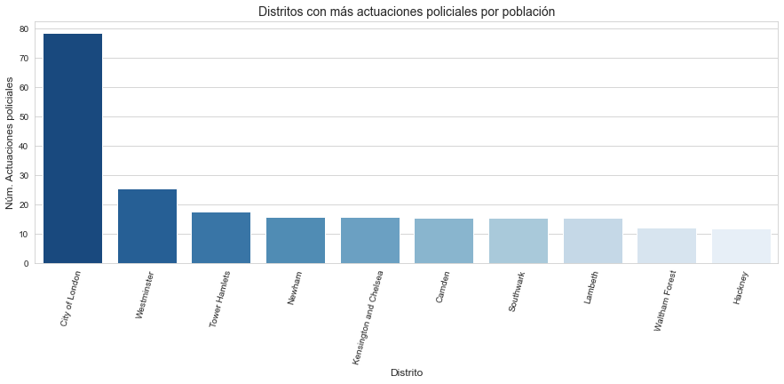

```python
# Distritos con más actuaciones policiales por población
top10 = pop_london_data.nlargest(10, 'Ratio')

plt.figure(figsize=(15, 5))
sns.set_style('whitegrid')
sns.barplot(x='Borough', y='Ratio', data=top10,
            order=top10.sort_values('Ratio', ascending=False).Borough, palette='Blues_r')
plt.xlabel('Distrito', size=12)
plt.ylabel('Núm. Actuaciones policiales', size=12)
plt.title('Distritos con más actuaciones policiales por población', size=14)
plt.xticks(rotation=75)
plt.show()
```

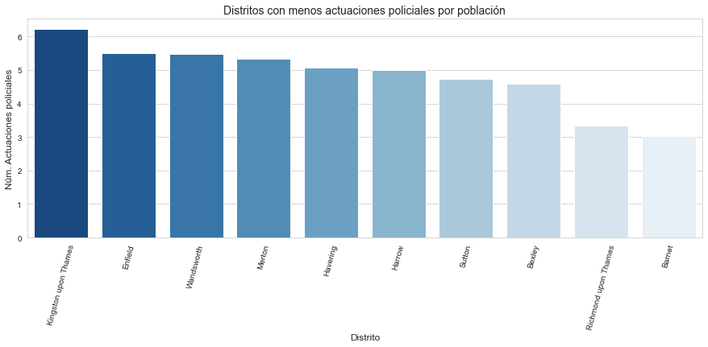

```python
# Distritos con menos actuaciones policiales por población
bottom10 = pop_london_data.nsmallest(10, 'Ratio')

plt.figure(figsize=(15, 5))
sns.set_style('whitegrid')
sns.barplot(x='Borough', y='Ratio', data=bottom10,
            order=bottom10.sort_values('Ratio', ascending=False).Borough, palette='Blues_r')
plt.xlabel('Distrito', size=12)
plt.ylabel('Núm. Actuaciones policiales', size=12)
plt.title('Distritos con menos actuaciones policiales por población', size=14)
plt.xticks(rotation=75)
plt.show()
```

```python
# Se genera un nuevo conjunto de datos para estudiar la ratio entre actuaciones policiales positivas
# y población por distrito
fa_pop_london_data = london_data.groupby('Borough', as_index=False)['Further-action'].sum()
fa_pop_london_data.rename(columns={'Further-action': 'Num-positives'}, inplace=True)

fa_pop_london_data = pd.merge(fa_pop_london_data, tot_ethnic_data, how='left', on=['Borough'])
fa_pop_london_data['Ratio'] = calculate_ratio(fa_pop_london_data['Num-positives'], fa_pop_london_data['Total'])
fa_pop_london_data.head(33)
```

|  | Borough | Num-positives | Total | Ratio |
| --- | --- | --- | --- | --- |
| 0 | Barking and Dagenham | 4500 | 185911 | 2.420513 |
| 1 | Barnet | 3001 | 356386 | 0.842065 |
| 2 | Bexley | 3141 | 231997 | 1.353897 |
| 3 | Brent | 7077 | 311215 | 2.273991 |
| 4 | Bromley | 5129 | 309392 | 1.657767 |
| 5 | Camden | 7786 | 220338 | 3.533662 |
| 6 | City of London | 1619 | 7375 | 21.952542 |
| 7 | Croydon | 9139 | 363378 | 2.515012 |
| 8 | Ealing | 6904 | 338449 | 2.039894 |
| 9 | Enfield | 4492 | 312466 | 1.437596 |
| 10 | Greenwich | 6191 | 254557 | 2.432068 |
| 11 | Hackney | 7630 | 246270 | 3.098226 |
| 12 | Hammersmith and Fulham | 4574 | 182493 | 2.506398 |
| 13 | Haringey | 7141 | 254926 | 2.801205 |
| 14 | Harrow | 3055 | 239056 | 1.277943 |
| 15 | Havering | 3355 | 237232 | 1.414227 |
| 16 | Hillingdon | 5420 | 273936 | 1.978564 |
| 17 | Hounslow | 5859 | 253957 | 2.307083 |
| 18 | Islington | 5942 | 206125 | 2.882717 |
| 19 | Kensington and Chelsea | 6614 | 158649 | 4.168952 |
| 20 | Kingston upon Thames | 2904 | 160060 | 1.814320 |
| 21 | Lambeth | 11029 | 303086 | 3.638901 |
| 22 | Lewisham | 6551 | 275885 | 2.374540 |
| 23 | Merton | 3031 | 199693 | 1.517830 |
| 24 | Newham | 11758 | 307984 | 3.817731 |
| 25 | Redbridge | 4972 | 278970 | 1.782270 |
| 26 | Richmond upon Thames | 1633 | 186990 | 0.873309 |
| 27 | Southwark | 10626 | 288283 | 3.685961 |
| 28 | Sutton | 2325 | 190146 | 1.222745 |
| 29 | Tower Hamlets | 10562 | 254096 | 4.156697 |
| 30 | Waltham Forest | 6639 | 258249 | 2.570775 |
| 31 | Wandsworth | 4437 | 306995 | 1.445300 |
| 32 | Westminster | 13051 | 219396 | 5.948604 |

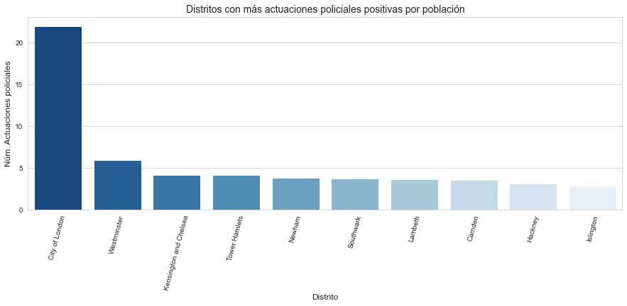

```python
# Distritos con más actuaciones policiales por población
top10 = fa_pop_london_data.nlargest(10, 'Ratio')

plt.figure(figsize=(15, 5))
sns.set_style('whitegrid')
sns.barplot(x='Borough', y='Ratio', data=top10,
            order=top10.sort_values('Ratio', ascending=False).Borough, palette='Blues_r')
plt.xlabel('Distrito', size=12)
plt.ylabel('Núm. Actuaciones policiales', size=12)
plt.title('Distritos con más actuaciones policiales positivas por población', size=14)
plt.xticks(rotation=75)
plt.show()
```

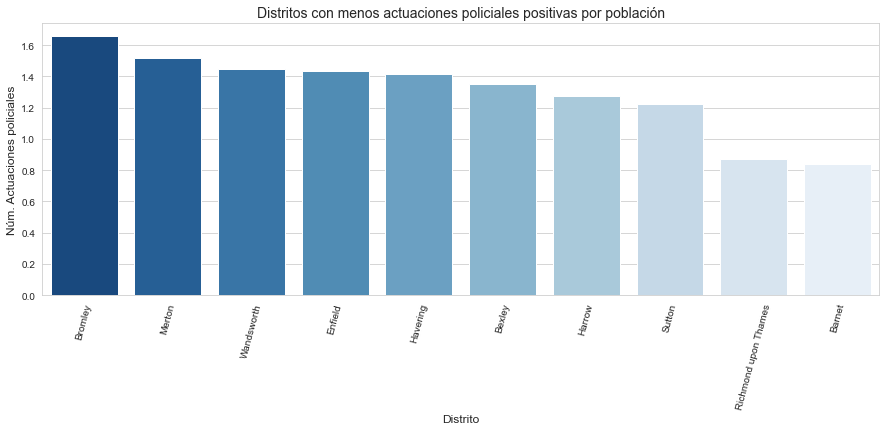

```python
# Distritos con menos actuaciones policiales por población
bottom10 = fa_pop_london_data.nsmallest(10, 'Ratio')

plt.figure(figsize=(15, 5))
sns.set_style('whitegrid')
sns.barplot(x='Borough', y='Ratio', data=bottom10,
            order=bottom10.sort_values('Ratio', ascending=False).Borough, palette='Blues_r')
plt.xlabel('Distrito', size=12)
plt.ylabel('Núm. Actuaciones policiales', size=12)
plt.title('Distritos con menos actuaciones policiales positivas por población', size=14)
plt.xticks(rotation=75)
plt.show()
```

### 2.4 Ingresos familiares por distrito

Elaboración de diversas gráficas relacionadas con los ingresos familiares por distrito.

```python
# Cruce de datos geográficos y de ingresos
map_data = london_map.set_index('NAME').join(income_data.set_index('Borough'))
map_data.head()
```

| NAME | GSS_CODE | HECTARES | NONLD_AREA | ONS_INNER | SUB_2009 | SUB_2006 | geometry | Income |
| --- | --- | --- | --- | --- | --- | --- | --- | --- |
| Kingston upon Thames | E09000021 | 3726.117 | 0.000 | F | None | None | POLYGON ((516401.600 160201.800, 516407.300 16... | 43940 |
| Croydon | E09000008 | 8649.441 | 0.000 | F | None | None | POLYGON ((535009.200 159504.700, 535005.500 15... | 37000 |
| Bromley | E09000006 | 15013.487 | 0.000 | F | None | None | POLYGON ((540373.600 157530.400, 540361.200 15... | 43060 |
| Hounslow | E09000018 | 5658.541 | 60.755 | F | None | None | POLYGON ((521975.800 178100.000, 521967.700 17... | 35330 |
| Ealing | E09000009 | 5554.428 | 0.000 | F | None | None | POLYGON ((510253.500 182881.600, 510249.900 18... | 36070 |

```python
# Tabla con ingresos familiares estimados (mediana) por distrito
income_data.head(33)
```

|  | Borough | Income |
| --- | --- | --- |
| 1104 | City of London | 63620 |
| 1105 | Barking and Dagenham | 29420 |
| 1106 | Barnet | 40530 |
| 1107 | Bexley | 36990 |
| 1108 | Brent | 32140 |
| 1109 | Bromley | 43060 |
| 1110 | Camden | 43750 |
| 1111 | Croydon | 37000 |
| 1112 | Ealing | 36070 |
| 1113 | Enfield | 33110 |
| 1114 | Greenwich | 35350 |
| 1115 | Hackney | 35140 |
| 1116 | Hammersmith and Fulham | 43820 |
| 1117 | Haringey | 35420 |
| 1118 | Harrow | 38880 |
| 1119 | Havering | 36670 |
| 1120 | Hillingdon | 37040 |
| 1121 | Hounslow | 35330 |
| 1122 | Islington | 39790 |
| 1123 | Kensington and Chelsea | 55620 |
| 1124 | Kingston upon Thames | 43940 |
| 1125 | Lambeth | 38490 |
| 1126 | Lewisham | 35900 |
| 1127 | Merton | 41960 |
| 1128 | Newham | 28780 |
| 1129 | Redbridge | 36860 |
| 1130 | Richmond upon Thames | 53470 |
| 1131 | Southwark | 37100 |
| 1132 | Sutton | 39940 |
| 1133 | Tower Hamlets | 34930 |
| 1134 | Waltham Forest | 33080 |
| 1135 | Wandsworth | 47480 |
| 1136 | Westminster | 47510 |

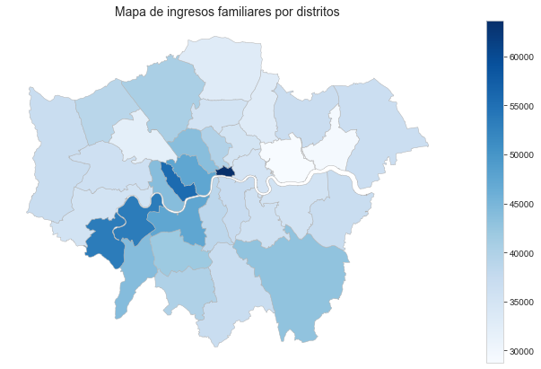

```python
# Se genera un mapa coroplético con los ingresos por distritos
fig, ax = plt.subplots(figsize=(15, 7))
ax.axis('off')
ax.set_title('Mapa de ingresos familiares por distritos', fontsize='14')
map_data.plot(column='Income', cmap='Blues', ax=ax, edgecolor='0.7', linewidth=0.5, legend=True)
```

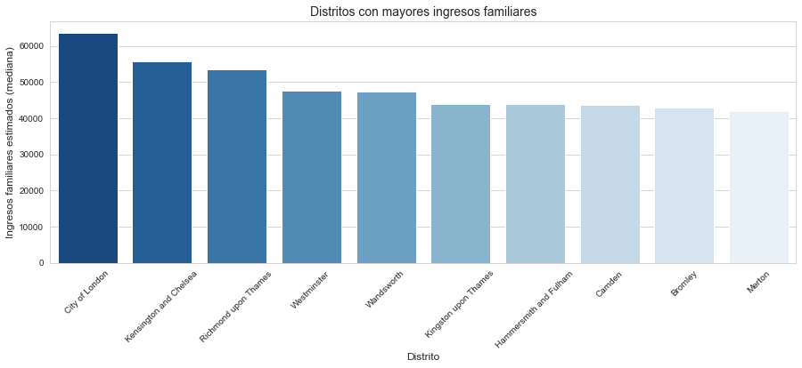

```python
# Gráfica con los distritos con mayores ingresos estimados por familia
top = income_data.nlargest(10, 'Income')

plt.figure(figsize=(15, 5))
sns.set_style('whitegrid')
sns.barplot(x='Borough', y='Income', data=top,
            order=top.sort_values('Income', ascending=False).Borough, palette='Blues_r')
plt.xlabel('Distrito', size=12)
plt.ylabel('Ingresos familiares estimados (mediana)', size=12)
plt.title('Distritos con mayores ingresos familiares', size=14)
plt.xticks(rotation=45)
plt.show()
```

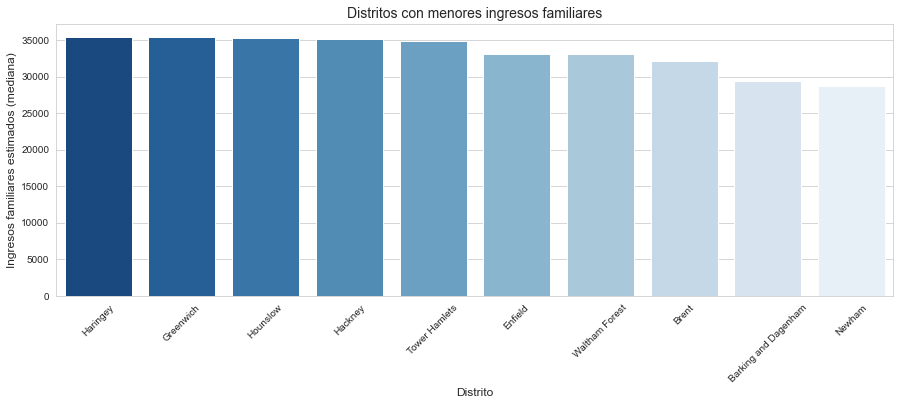

```python
# Gráfica con los distritos con menores ingresos estimados por familia
bottom = income_data.nsmallest(10, 'Income')

plt.figure(figsize=(15, 5))
sns.set_style('whitegrid')
sns.barplot(x='Borough', y='Income', data=bottom,
            order=bottom.sort_values('Income', ascending=False).Borough, palette='Blues_r')
plt.xlabel('Distrito', size=12)
plt.ylabel('Ingresos familiares estimados (mediana)', size=12)
plt.title('Distritos con menores ingresos familiares', size=14)
plt.xticks(rotation=45)
plt.show()
```

### 2.5 Ratio de actuaciones policiales por población y distrito (ordenado por ingresos)

```python
# Cruce entre el dataframe de población y el de income
pop_london_data = pd.merge(pop_london_data, income_data, how='left', on=['Borough'])
pop_london_data.head(33)
```

|  | Borough | Num-stops | Total | Ratio | Income |
| --- | --- | --- | --- | --- | --- |
| 0 | Barking and Dagenham | 15208 | 185911 | 8.180258 | 29420 |
| 1 | Barnet | 10797 | 356386 | 3.029580 | 40530 |
| 2 | Bexley | 10674 | 231997 | 4.600922 | 36990 |
| 3 | Brent | 28477 | 311215 | 9.150266 | 32140 |
| 4 | Bromley | 20195 | 309392 | 6.527318 | 43060 |
| 5 | Camden | 33966 | 220338 | 15.415407 | 43750 |
| 6 | City of London | 5800 | 7375 | 78.644068 | 63620 |
| 7 | Croydon | 34391 | 363378 | 9.464249 | 37000 |
| 8 | Ealing | 28056 | 338449 | 8.289580 | 36070 |
| 9 | Enfield | 17163 | 312466 | 5.492758 | 33110 |
| 10 | Greenwich | 24707 | 254557 | 9.705881 | 35350 |
| 11 | Hackney | 28869 | 246270 | 11.722500 | 35140 |
| 12 | Hammersmith and Fulham | 17186 | 182493 | 9.417348 | 43820 |
| 13 | Haringey | 29703 | 254926 | 11.651617 | 35420 |
| 14 | Harrow | 11922 | 239056 | 4.987116 | 38880 |
| 15 | Havering | 12010 | 237232 | 5.062555 | 36670 |
| 16 | Hillingdon | 19891 | 273936 | 7.261185 | 37040 |
| 17 | Hounslow | 22057 | 253957 | 8.685329 | 35330 |
| 18 | Islington | 23733 | 206125 | 11.513887 | 39790 |
| 19 | Kensington and Chelsea | 24899 | 158649 | 15.694395 | 55620 |
| 20 | Kingston upon Thames | 9954 | 160060 | 6.218918 | 43940 |
| 21 | Lambeth | 46455 | 303086 | 15.327333 | 38490 |
| 22 | Lewisham | 22372 | 275885 | 8.109176 | 35900 |
| 23 | Merton | 10657 | 199693 | 5.336692 | 41960 |
| 24 | Newham | 48579 | 307984 | 15.773222 | 28780 |
| 25 | Redbridge | 19717 | 278970 | 7.067785 | 36860 |
| 26 | Richmond upon Thames | 6261 | 186990 | 3.348307 | 53470 |
| 27 | Southwark | 44384 | 288283 | 15.395982 | 37100 |
| 28 | Sutton | 8999 | 190146 | 4.732679 | 39940 |
| 29 | Tower Hamlets | 44730 | 254096 | 17.603583 | 34930 |
| 30 | Waltham Forest | 31532 | 258249 | 12.209921 | 33080 |
| 31 | Wandsworth | 16821 | 306995 | 5.479242 | 47480 |
| 32 | Westminster | 55556 | 219396 | 25.322248 | 47510 |

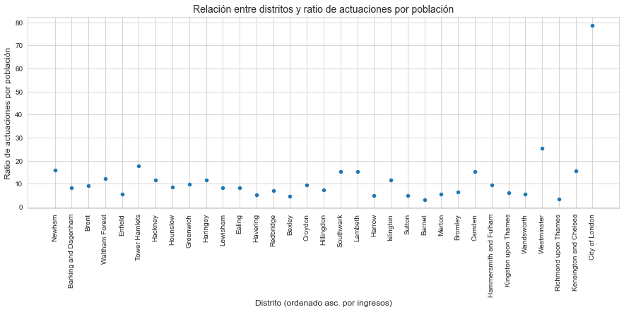

```python
# Se ordenan los distritos por ingresos familiares
pop_london_data.sort_values(by=['Income'], inplace=True)

# Se muestra un gráfico de dispersión
plt.figure(figsize=(15, 5))
sns.set_style('whitegrid')
sns.scatterplot(x='Borough', y='Ratio', data=pop_london_data)
plt.xlabel('Distrito (ordenado asc. por ingresos)', size=12)
plt.ylabel('Ratio de actuaciones por población', size=12)
plt.title('Relación entre distritos y ratio de actuaciones por población', size=14)
plt.xticks(rotation=90)
plt.show()
```